# Univariate Plots Section

# The data is right skewed, The highest is at 5 .

```r
  summary(red_wine2$free.sulfur.dioxide)
```

```
##    Min. 1st Qu.  Median    Mean 3rd Qu.    Max.
##    1.00    7.00   14.00   15.87   21.00   72.00
```

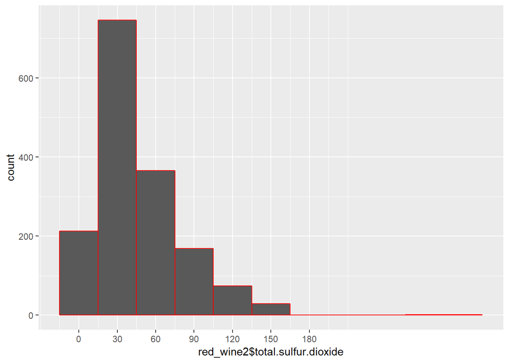

# Right skewed data. With the highest between 15 and 45.

```r
  summary(red_wine2$total.sulfur.dioxide)
```

```
##    Min. 1st Qu.  Median    Mean 3rd Qu.    Max.
##    6.00   22.00   38.00   46.47   62.00  289.00
```

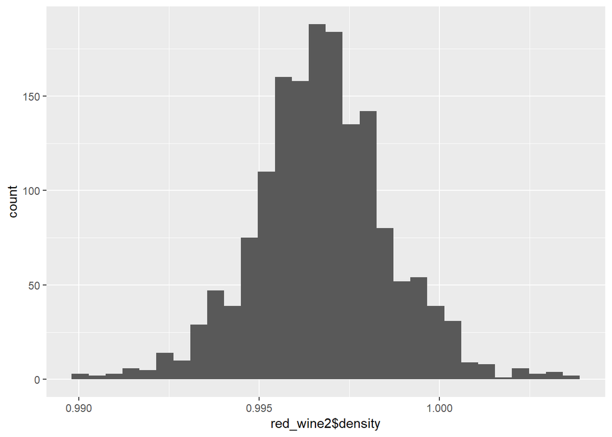

# The data in the previous graph is normally distributed .

```r
  summary(red_wine2$density)
```

```
##    Min. 1st Qu.  Median    Mean 3rd Qu.    Max.
##  0.9901  0.9956  0.9968  0.9967  0.9978  1.0037
```

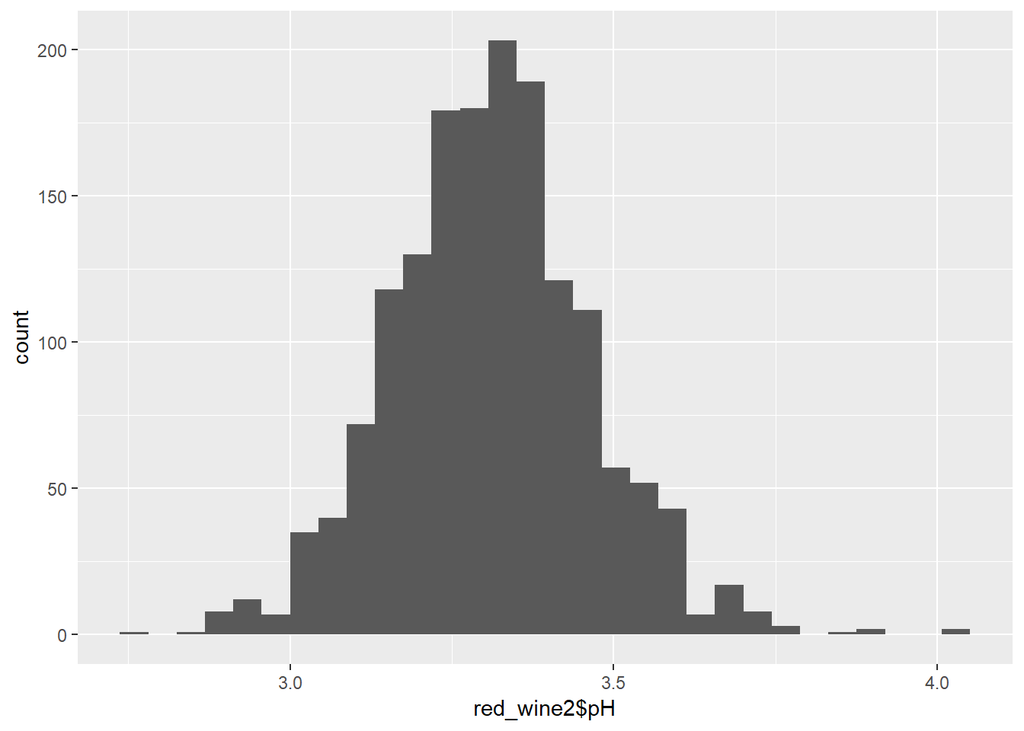

# normally distributed data

```r
  summary(red_wine2$pH)
```

```
##    Min. 1st Qu.  Median    Mean 3rd Qu.    Max.
##   2.740   3.210   3.310   3.311   3.400   4.010
```

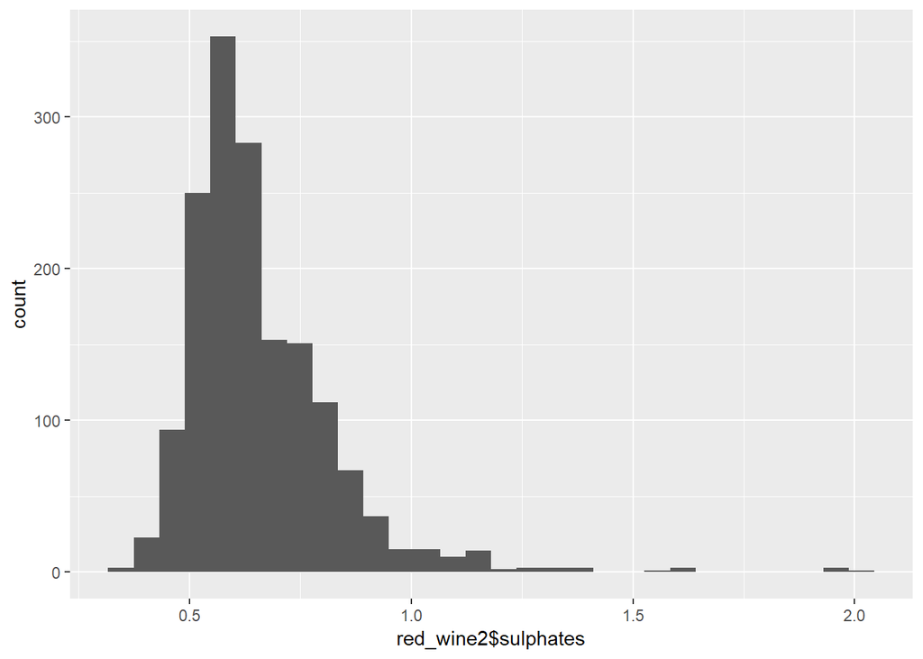

# normally distributed with a tail.

```r
  summary(red_wine2$sulphates)
```

```
##    Min. 1st Qu.  Median    Mean 3rd Qu.    Max.
##  0.3300  0.5500  0.6200  0.6581  0.7300  2.0000
```

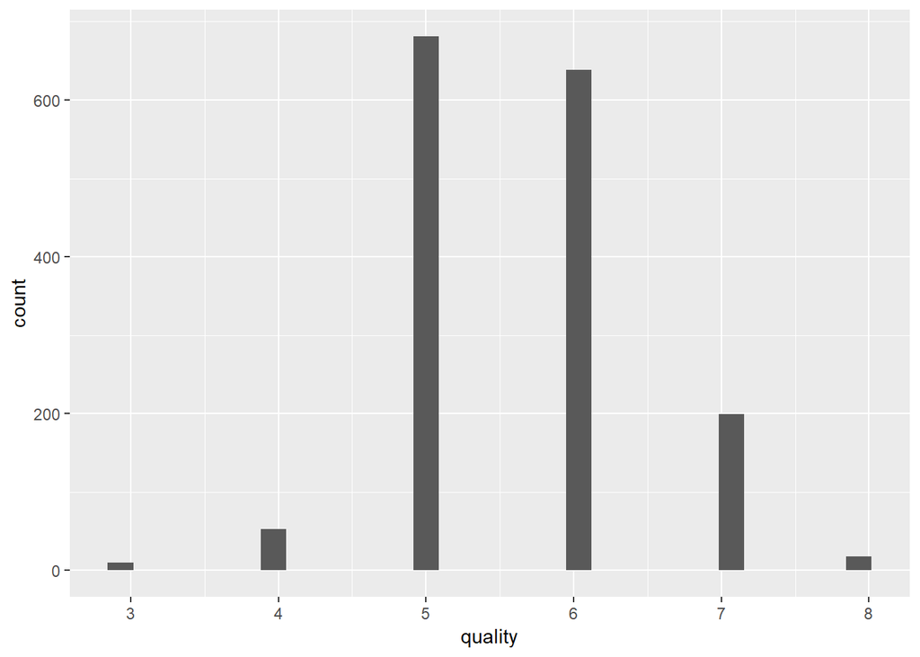

The highest quality is at 5 then 6 .

```r
  summary(red_wine2$quality)
```

```
##    Min. 1st Qu.  Median    Mean 3rd Qu.    Max.
##   3.000   5.000   6.000   5.636   6.000   8.000
```

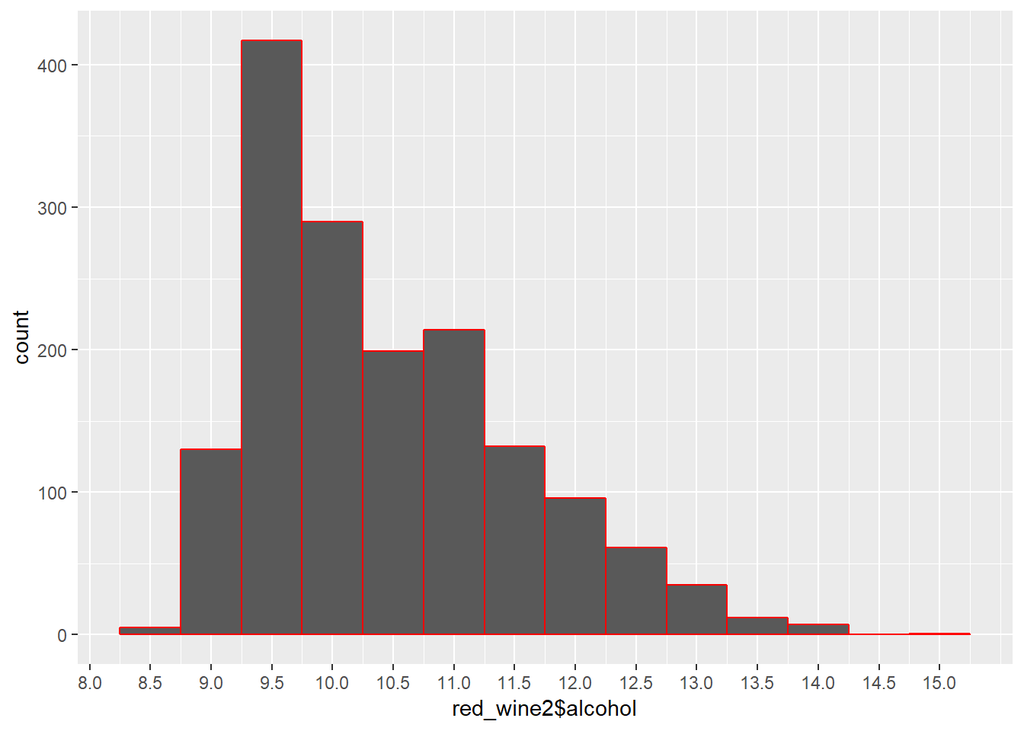

# The highest alcohol is in the range 9.25 to 9.75

```r
  summary(red_wine2$alcohol)
```

```
##    Min. 1st Qu.  Median    Mean 3rd Qu.    Max.
##    8.40    9.50   10.20   10.42   11.10   14.90
```

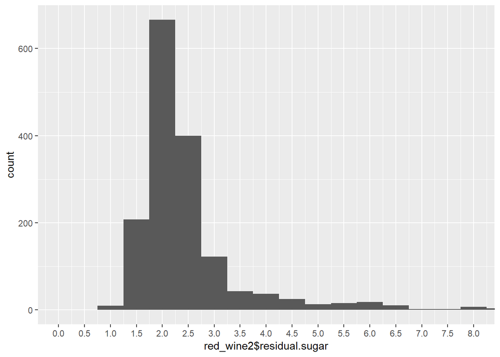

```r
ggplot(data = red_wine2 ,aes(x=red_wine2$residual.sugar))+
  geom_histogram(binwidth = 0.5)+
  scale_x_continuous(breaks=seq(0,8,0.5))+
  coord_cartesian(xlim = c(0,8))
```

# the highest count for residual sugar is between 1.75 to 2.25 and there are some outliers in the end

```r
  summary(red_wine2$residual.sugar)
```

```
##    Min. 1st Qu.  Median    Mean 3rd Qu.    Max.
##   0.900   1.900   2.200   2.539   2.600  15.500
```

> **Tip**: Make sure that you leave a blank line between the start / end of each code block and the end / start of your Markdown text so that it is formatted nicely in the knitted text. Note as well that text on consecutive lines is treated as a single space. Make sure you have a blank line between your paragraphs so that they too are formatted for easy readability.

# Univariate Analysis

> **Tip**: Now that you’ve completed your univariate explorations, it’s time to reflect on and summarize what you’ve found. Use the questions below to help you gather your observations and add your own if you have other thoughts!

### What is the structure of your dataset?

The structure of the data in the beginning was 13 variable but I dropped 1 of them because it was just the id , all the columns are num but Only quality is int . The highest proportion of quality is at 5. The lowest quality is 3 while the highest quality is 8 .

### Did you perform any operations on the data to tidy, adjust, or change the form of the data? If so, why did you do this?

no

# Bivariate Plots Section

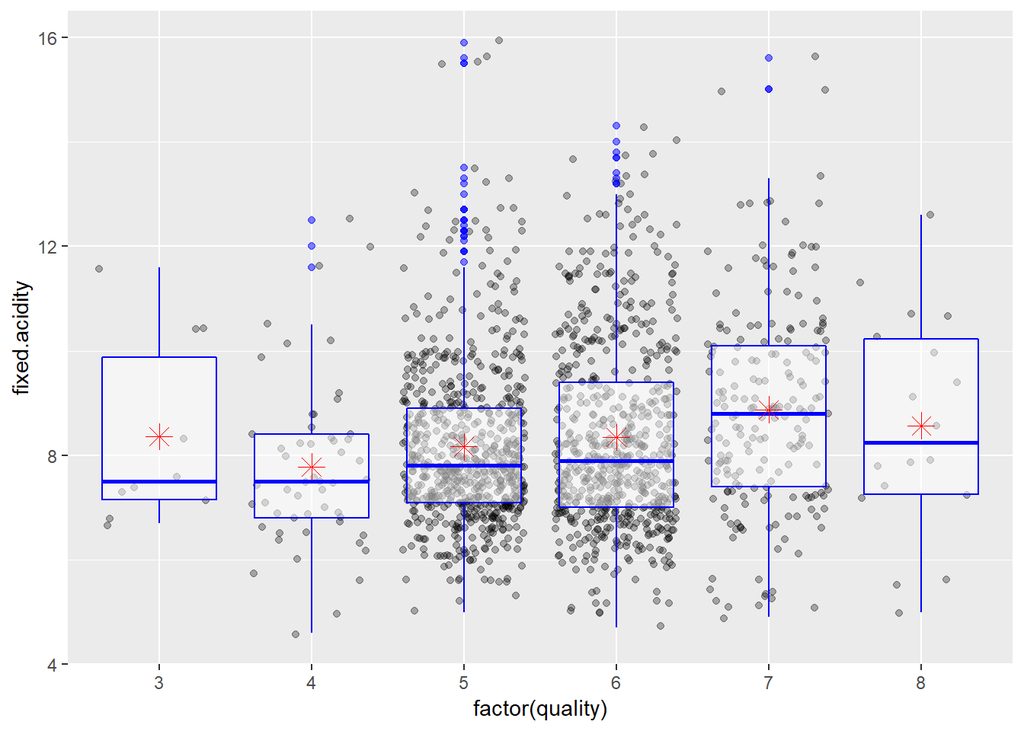